# Final_M

Author

Abhishek_Bargujar

# Overview

In this piece, I’ll look at the characteristics of superheroes and compare and contrast the superheroes from DC and Marvel Comics according to there qualities. I’ll try to highlight the parallels and discrepancies across superheroes in every realm.

This data set contains all about heroes from the Marvel and DC universes, including their pros and disadvantages, power levels, durability (how they handle attacks), intelligence, and combat abilities.

Data_Source: ->

1. https://www.kaggle.com/code/adilemrebilgic/marvel-super-heroes/input (here i choose 3 csv files for heroes dataset and modify it little bit)
2. https://www.kaggle.com/datasets/spatika/marvel-comics-characters-stats-and-powers/data ( here i get the idea of choosing heros dataset and what to do with it).

In marvel_characters_info i add weight column too.. and little bit edit the dataset. In characters_stats.csv —-> change to characterStats superheroes_power_matrix.csv –> change to super power marvel_characters_info —> change to heroes information.

## Importing Libraries

(a). Tidyverse: A collection of packages for data manipulation and analysis that follow the principles of tidy data and share a common philosophy,including packages like dplyr,ggplot2, and tidyr

(b).dplyr:In the tidyverse, dplyr is a more simplified and effective package for typical data manipulation operations including summarizing, filtering, and choosing.

(c).plyr: A flexible package for data splitting, function application, and result combining is called plyr.

(d). tidyr:with features for handling missing values, rearranging columns, and converting between wide and long formats, the tidyverse package tidyr in R helps tidy and reshape data, enabing effective data analysis and visualization.

(e).reshape2: Efficient data reshaping is made possibly by the R reshape2 package, which converts data between wide and long formats for better analysis and display.

(f).readr: Provides functions for reading rectangular data (like CSV files) quickly and easily into R.

(e).GridExtra: The gridExtra package in R expands the grid graphics system by enabling the layout and combining of several grid-based charts on a single page.

(f). ggplot2: Data Visualization is made easier with the help of the R ggplot2 library, which uses a declarative vocabulary to produce expressive and adaptable charts.

## Importing, Inspecting & Preparing The Data sets

(a). The Weight & Height columns appear to include a large number -99 values. that is most I likely the result of missing values because these variables cannot have negative values and all have the same value. To ensure that they have no bearing on the analysis, I am converting them to NA’s.

(b). Additionally, the class needs to be changed for the variables found in both datasets. I’ll give them everyone an update.

(c).In order to improve performance, I will convert all of the missing values on the two datasets that are indicated by the symbol “-” to NAs.

```r
infoCharacters <- read.csv("heroesInformation.csv", na.strings = c("-", "-99"))
infoPowers <- read.csv("superHeroPowers.csv")
infoStats <- read.csv("charactersStats.csv", na.strings = "")
#infoCharacters
#infoPowers
#infoStats
```

## Checking Height of Heroes

The line chart displays the heights of the first 15 superheroes. Each superhero’s name is plotted against their height, providing a visual representation of their heights. The chart allows us to compare the heights of different superheroes at a glance.

AS i can see that from 15 characters most of them height between 165 cm to 195 cm and for assumption i can say that most heroes height fall in between range 165 cm to 195 cm. and this height parameter is also kind of power like some superhero have power to change there height accordingly…

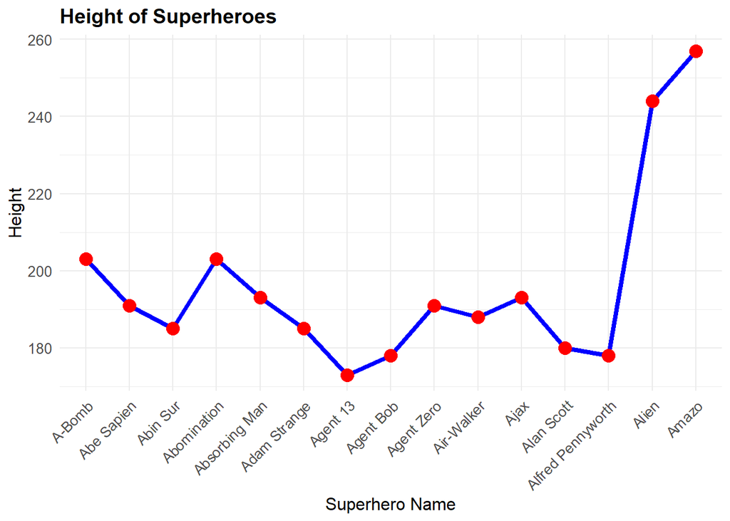

```r
infoCharacters <- infoCharacters[complete.cases(infoCharacters$Height) & infoCharacters$Height >= 0, ]


ggplot(infoCharacters[1:15,], aes(x = name, y = Height, group = 1)) +
  geom_line(linewidth = 1.5, linetype = "solid", color = "blue") +
  geom_point(size = 4, shape = 16, color = "red") +
  labs(title = 'Height of Superheroes',
       x = 'Superhero Name',
       y = 'Height') +
  theme_minimal() +
  theme(axis.text.x = element_text(angle = 45, hjust = 1, vjust = 1),
        axis.text = element_text(size = 10),
        axis.title = element_text(size = 12),
        plot.title = element_text(size = 14, face = "bold"))
```

### Most Common Eye color

- To visualizing the distribution of categorical data, I have created a count plot for the ‘Eye color’ column. The plot displays the frequency of each eye color among the characters in the dataset.
- There are lots of character with ‘Blue’ color eye , brown followed by green eye color…

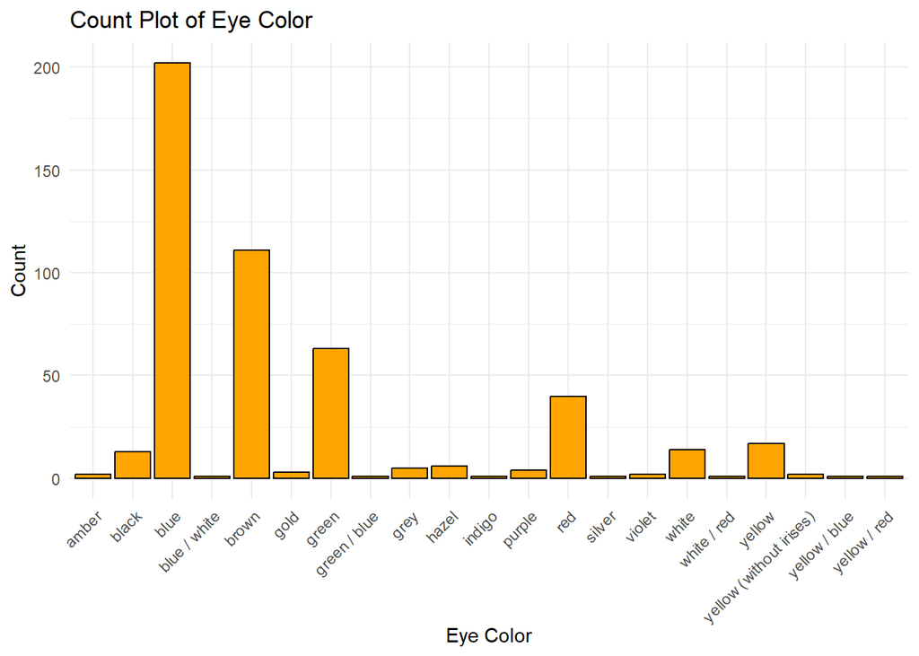

```r
infoCharacters <- infoCharacters[!is.na(infoCharacters$`Eye.color`),]

# Creating a count plot
EyecountPlot <- ggplot(infoCharacters, aes(x = `Eye.color`)) +
  geom_bar(fill = 'orange', color = 'black') +
  labs(title = "Count Plot of Eye Color", x = "Eye Color", y = "Count") +
  theme_minimal() +
  theme(axis.text.x = element_text(angle = 45, hjust = 1))

EyecountPlot
```

## Finding Heroes Most common weight

The code generates a scatter plot of superhero weights, providing insights into the distribution and variation of weights among superheroes in the dataset, while also taking steps to handle missing values.

Most eroes weight falls under 50 to 210lbs..

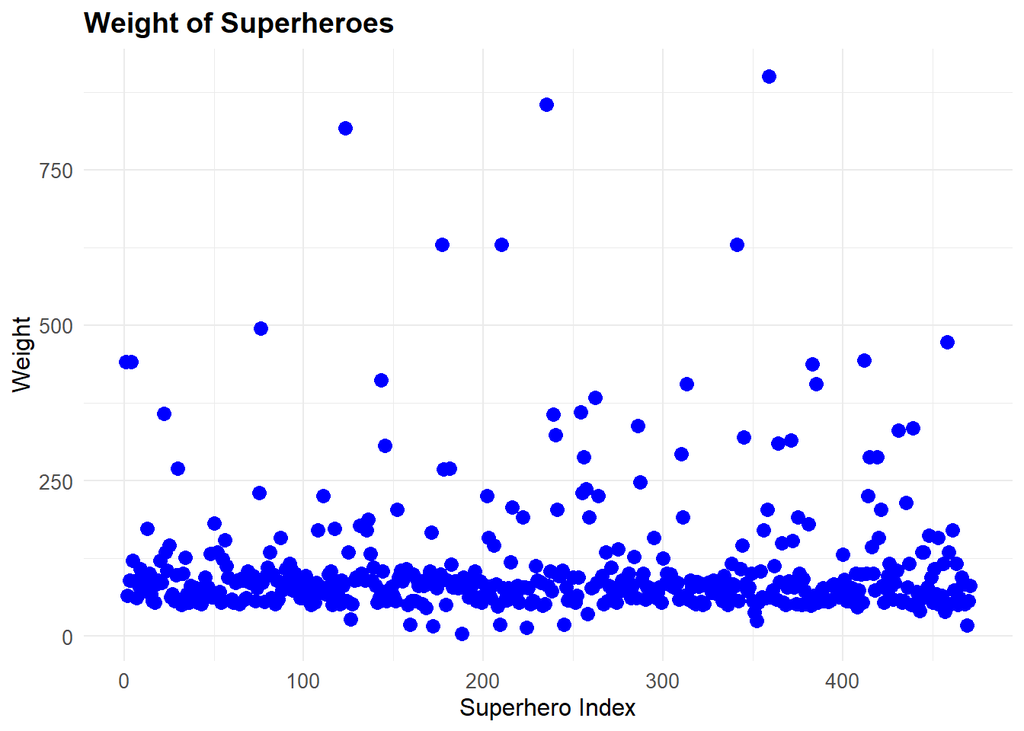

```r
# Removing missing values
infoCharacters <- infoCharacters[complete.cases(infoCharacters$Weight) & infoCharacters$Weight >= 0, ]

wgtPlot <- ggplot(infoCharacters, aes(x = seq_along(Weight), y = Weight)) +
  geom_point(color = 'blue', size = 3) +
  labs(title = 'Weight of Superheroes',
       x = 'Superhero Index',
       y = 'Weight') +
  theme_minimal() +
  theme(axis.text = element_text(size = 10),
        axis.title = element_text(size = 12),
        plot.title = element_text(size = 14, face = "bold"))

wgtPlot
```

## Pie Chart

The pie chart shows the proportions of “Good” and “Bad” alignments among the superheroes. It visually represents the distribution of superhero alignments, allowing us to see the relative proportions of each alignment type. This provides insight into the overall distribution of superhero alignments in the dataset

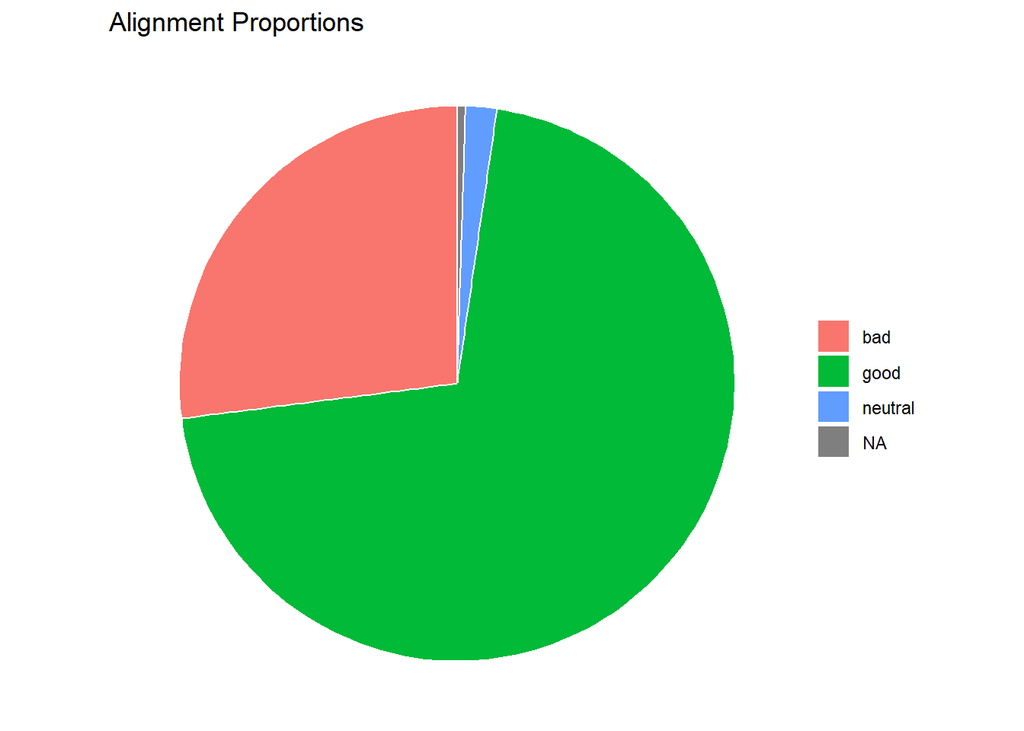

```r
ggplot(infoStats, aes(x = "", fill = Alignment)) +
  geom_bar(width = 1, color = "white") +
  coord_polar(theta = "y") +
  theme_void() +
  labs(title = 'Alignment Proportions',
       fill = 'Alignment') +
  theme(legend.position = "right", legend.title = element_blank())  # Adjusting legend position and removing title
```

## Checking Durability Frequency

The histogram visualizes the frequency distribution of ‘Durability’ values in the ‘infoStats’ dataset, offering insights into the prevalence and concentration of different durability levels. The binwidth of 20 allows for a broader view of the dataset’s distribution.

This code visualizing how frequently different Durability values occur in this dataset, providing insights into the distribution of Durability in the ‘infoStats’ dataset.

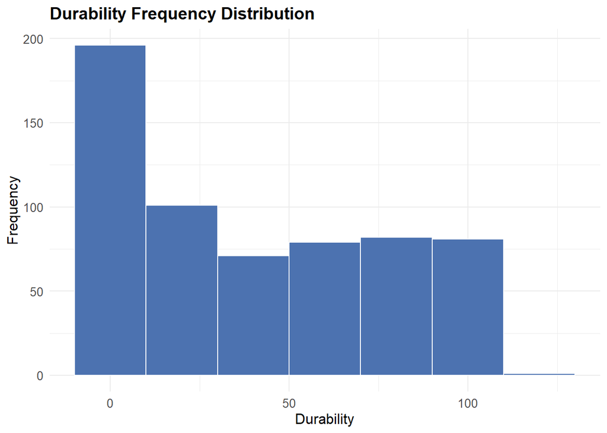

```r
ggplot(infoStats, aes(x = Durability, fill = ..count..)) +
  geom_histogram(binwidth = 20, color = "white", fill = "#4C72B0") +
  labs(title = 'Durability Frequency Distribution',
       x = 'Durability',
       y = 'Frequency') +
  theme_minimal() +
  theme(axis.text = element_text(size = 10),
        axis.title = element_text(size = 12),
        plot.title = element_text(size = 14, face = "bold"))
```

## Calculating Speed and Power together

[figure not shown]

```r
# Selecting the top 38 heroes based on a criterion
top_heroes <- infoStats %>% arrange(desc(Speed + Power)) %>% head(38)

# Create a bar plot
ggplot(top_heroes, aes(x = reorder(Name, -(Speed + Power)), y = Speed + Power, fill = "Total")) +
  geom_bar(stat = "identity", position = "dodge", color = "white") +
  labs(title = 'Top 38 Heroes - Speed + Power',
       x = 'Hero Name',
       y = 'Total Value') +
  scale_fill_manual(values = "blue", guide = FALSE) +
  theme_minimal() +
  theme(axis.text.x = element_text(angle = 45, hjust = 1, size = 8),
        axis.text.y = element_text(size = 8),
        axis.title = element_text(size = 10, face = "bold"),
        plot.title = element_text(size = 12, face = "bold"))
```

## Subset for Marvel and DC

- In the infoCharacters data frame, changing the column name from “name” to “Name”.
- Creating a new data frame called marvelDcInfo and fill it with only the infoCharacters rows where “Publisher” is either “Marvel Comics” or “DC Comics”

```r
colnames(infoCharacters)[colnames(infoCharacters) == "name"] <- "Name"
marvelDcInfo <- infoCharacters[(infoCharacters$Publisher == "Marvel Comics" | infoCharacters$Publisher == "DC Comics"), ]
```

## Removing Name Duplicates And Select Columns

- I’ll only compare two of the data because the most of them are superheroes from Marvel or DC Comics.That’s why i selects only rows where the “Publisher” is either “Marvel Comics” or “DC Comics”.
- keep only distinct rows based on the “Name” column & Select Specific columns.

```r
marvelDcInfo <- marvelDcInfo[!duplicated(marvelDcInfo$Name), ]
marvelDcInfo <- marvelDcInfo %>%
  select(Name, Gender, Race, Publisher)
```

## Joining the Data sets

- This code joins three data sets(marvelDcInfo, infoStats, and infoPowers) to merge character information from DC and Marvel Comics. A consolidated dataset for analysis or exploration is produced by integrating statistics and powers information based on the names of the characters in the final dataset, fullMarvelDc.

-> I load dplyr and plyr packages because join operations is not working.

```r
marvelDcStatsInfo <- join(marvelDcInfo, infoStats, by = "Name", type = "inner")

colnames(infoPowers)[colnames(infoPowers) == "hero_names"] <- "Name"
fullMarvelDc <- join(marvelDcStatsInfo, infoPowers, by = "Name", type = "inner")
```

## Transforming Variable column Into A Single Column Super Power

- In this code reshapes and filters a data frame(fullMarvelDC) containing Marvel and DC Character information by melting into a long format,renaming columns, and selecting rows where superpowers are true, resulting in a condensed (refers to reducing data set by selecting only specific column),repersentation of characters and their powers.

```r
marvelDc <- melt(fullMarvelDc, id = c("Name", "Gender", "Race", "Publisher", "Alignment", "Intelligence",
                                         "Strength", "Speed", "Durability", "Power", "Combat", "Total"))

colnames(marvelDc)[colnames(marvelDc) == "variable"] <- "SuperPower"

marvelDc <- marvelDc %>%
  filter(value == "True") %>%
  select(-value)
```

## Converting Categorical Columns To Factors

- Here i uses the as.factor() method, which is frequently done in R to represent categorical variables for easier handling in statistical analysis or graphing, to transform several columns in the marvelDc data frame to the factor data type.

```r
marvelDc$Name <- as.factor(marvelDc$Name)
marvelDc$Gender <- as.factor(marvelDc$Gender)
marvelDc$Race <- as.factor(marvelDc$Race)
marvelDc$Publisher <- as.factor(marvelDc$Publisher)
marvelDc$Alignment <- as.factor(marvelDc$Alignment)
marvelDc$SuperPower <- as.factor(marvelDc$SuperPower)
```

## Data Observations in Each Publisher

- In the marvelDc data frame, to show the total number of characters for DC and Marvel companies. Characters counts are labeled on each bar and a custom color palette(dcMarvelPalette) is used.The plot provides a concise overview of character distribution between the two publishers.
- Marvel has more superheroes characters than DC.

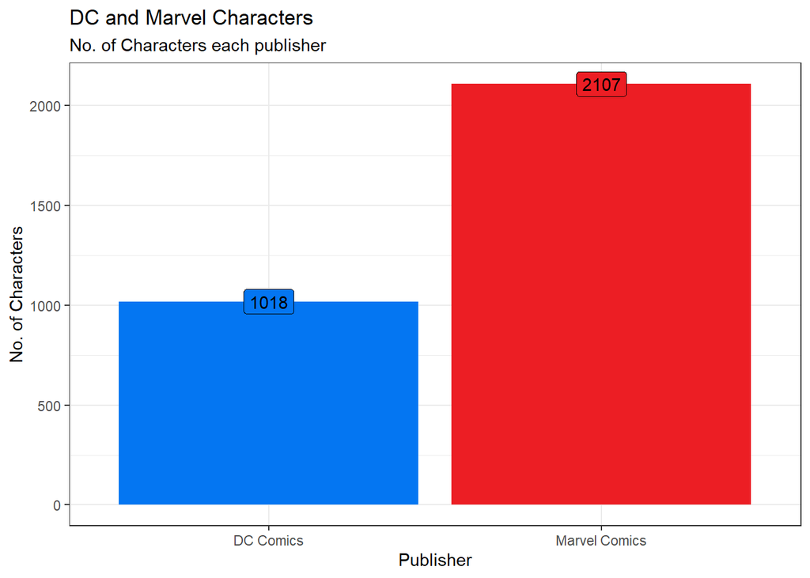

```r
dcMarvelPalette <- c("#0476F2", "#EC1E24")
goodBadPalette <- c("#E58700", "#0EBF7D", "#C99902")

# DATA OBSERVATIONS IN EACH PUBLISHER

ggplot(marvelDc, aes(x = Publisher, fill = Publisher)) +
  geom_bar(stat = "count", aes(fill = Publisher)) +
  labs(x = "Publisher", y = "No. of Characters", title = "DC and Marvel Characters", subtitle = "No. of Characters each publisher") +
  geom_label(stat = "count", aes(label = ..count..)) +
  guides(fill = FALSE) +
  theme_bw() +
  scale_fill_manual(values=dcMarvelPalette)
```

## Males And Females IN DC And Marvel

- using a grouped bar plot, this code analyzes and displays the gender distribution of characters in the ‘marvelDc’ dataset for the DC and Marvel companies. A breif comparison of character counts by gender for each publisher is given by the resulting plot.
- Marvel and DC universe both have more male characters than female characters.
- Marvel has more female characters than DC.

```r
marvelDcGender <- marvelDc %>%
  filter(!is.na(Gender)) %>%
  group_by(Gender) %>%
  dplyr::count(Publisher) %>%
  select(Gender, Publisher, Count = n)
```

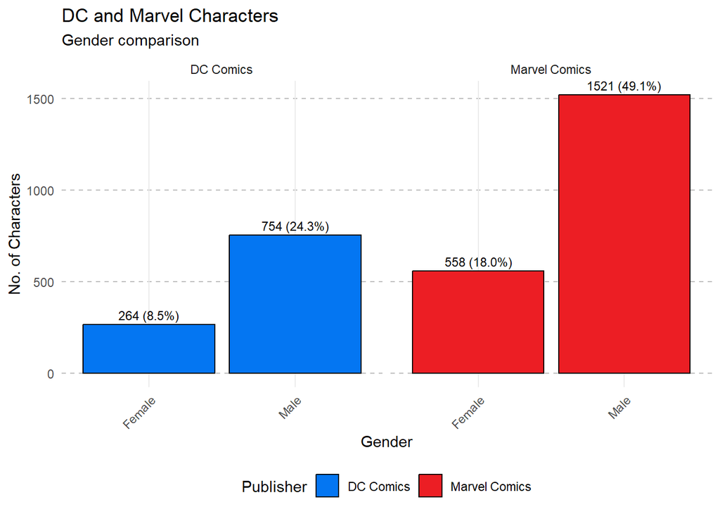

```r
ggplot(marvelDcGender, aes(x = Gender, y = Count, fill = Publisher)) +
  geom_col(position = "dodge", color = "black", size = 0.5) +
  geom_text(aes(label = paste0(Count, " (", scales::percent(Count/sum(Count)), ")")),
            position = position_dodge(width = 0.9), vjust = -0.5, size = 3) +
  labs(x = "Gender", y = "No. of Characters", title = "DC and Marvel Characters", subtitle = "Gender comparison") +
  facet_wrap(~Publisher) +
  theme_minimal() +
  scale_fill_manual(values = dcMarvelPalette) +
  theme(axis.text.x = element_text(angle = 45, hjust = 1),
        panel.grid.major.y = element_line(color = "gray", linetype = "dashed"),
        panel.grid.minor.y = element_blank(),
        legend.position = "bottom")
```

## Checking Danger Sense and Accelerated Healing in Heroes

As i using infopower dataset that contain binary values so deal with binary values i am doing sub setting with value.

As I can see that out of 15 super heroes only 2 got Danger Sense Alan Scott, Alex Mercer and 5 got Accelerated Healing power out of 15. and only one hero who get both powers is “Alex Mercer”.

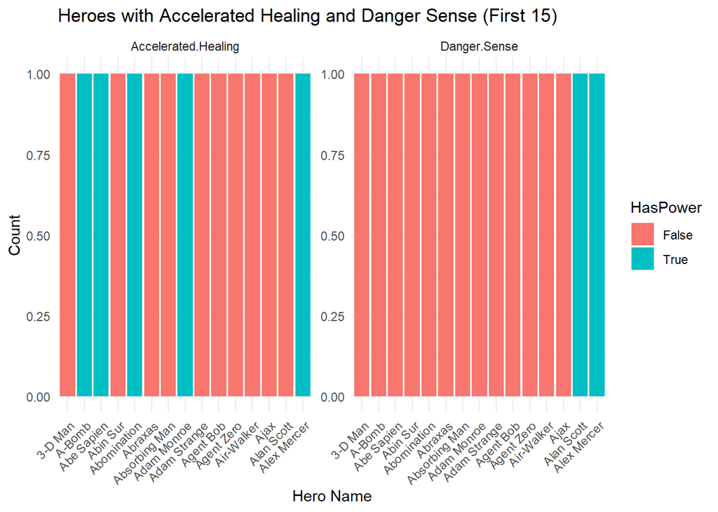

```r
library(tidyr)

# Subseting the dataset for the specified columns and the first 15 superheroes
subset_data <- infoPowers[1:15, c("Name", "Accelerated.Healing", "Danger.Sense")]

# Reshaping the data for plotting
tidy_data <- gather(subset_data, key = "Power", value = "HasPower", -Name)

# Ploting grouped bar plot
ggplot(tidy_data, aes(x = Name, fill = HasPower)) +
  geom_bar(stat = "count", position = "dodge") +
  facet_wrap(~ Power, scales = "free_y") +
  labs(title = 'Heroes with Accelerated Healing and Danger Sense (First 15)',
       x = 'Hero Name',
       y = 'Count') +
  theme_minimal() +
  theme(axis.text.x = element_text(angle = 45, hjust = 1))
```

## Race Difference Between Marvel And DC

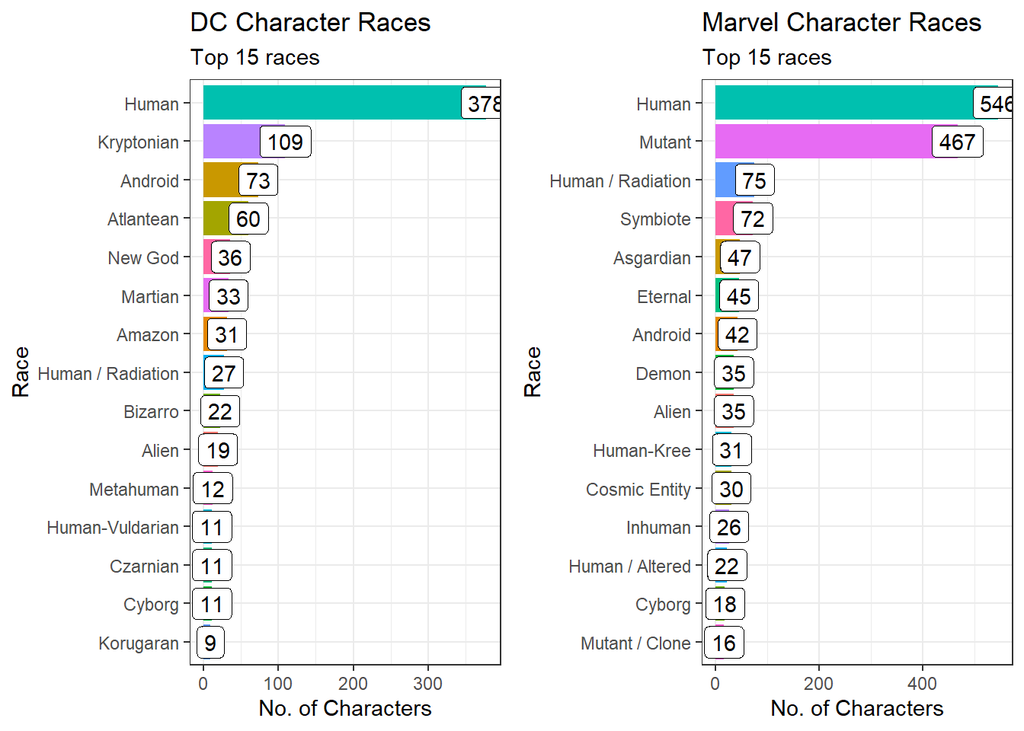

```r
DCRace <- marvelDc %>%
  filter(!is.na(Race)) %>%
  filter(Publisher == "DC Comics") %>%
  group_by(Race) %>%
  dplyr::count(Race) %>%
  select(Race, Count = n) %>%
  arrange(-Count)

DCRace <- ggplot(DCRace[1:15, ], aes(x = reorder(Race, Count), y = Count)) +
  geom_bar(stat = "identity", aes(fill = Race)) +
  labs(x = "Race", y = "No. of Characters", title = "DC Character Races", subtitle= "Top 15 races") +
  geom_label(stat = "identity", aes(label = Count)) +
  coord_flip() +
  guides(fill = FALSE, alpha = FALSE) +
  theme_bw()

marvelRace <- marvelDc %>%
  filter(!is.na(Race)) %>%
  filter(Publisher == "Marvel Comics") %>%
  group_by(Race) %>%
  dplyr::count(Race) %>%
  select(Race, Count = n) %>%
  arrange(-Count)

marvelRace <- ggplot(marvelRace[1:15, ], aes(x = reorder(Race, Count), y = Count)) +
  geom_bar(stat = "identity", aes(fill = Race)) +
  geom_label(stat = "identity", aes(label = Count)) +
  labs(x = "Race", y = "No. of Characters", title = "Marvel Character Races", subtitle= "Top 15 races") +
  coord_flip() +
  guides(fill = FALSE, alpha = FALSE) +
  theme_bw()

grid.arrange(DCRace, marvelRace, ncol = 2)
```

## Heroes and Villains IN Marvel And DC

Heroes –> Good, Villains–> Bad, Neutral –> those characters who involve in crime and also in helping people.

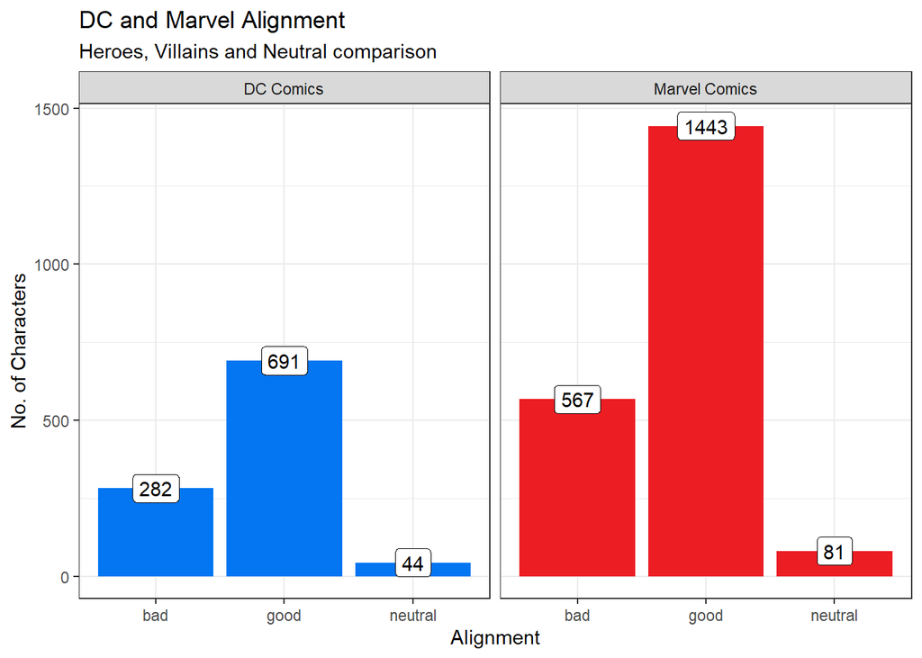

```r
marvelDcAlignment <- marvelDc %>%
  filter(!is.na(Alignment)) %>%
  group_by(Alignment) %>%
  dplyr::count(Publisher) %>%
  select(Alignment, Publisher, Count = n)

ggplot(marvelDcAlignment, aes(x = Alignment, y = Count)) +
  geom_bar(stat = "identity", aes(fill = Publisher)) +
  labs(x = "Alignment", y = "No. of Characters", title = "DC and Marvel Alignment", subtitle= "Heroes, Villains and Neutral comparison") +
  guides(fill = FALSE) +
  geom_label(stat = "identity", aes(label = Count)) +
  facet_wrap(~Publisher) +
  theme_bw() +
  scale_fill_manual(values=dcMarvelPalette)
```

### Alternative of previous plot that just simply show the exact numbers

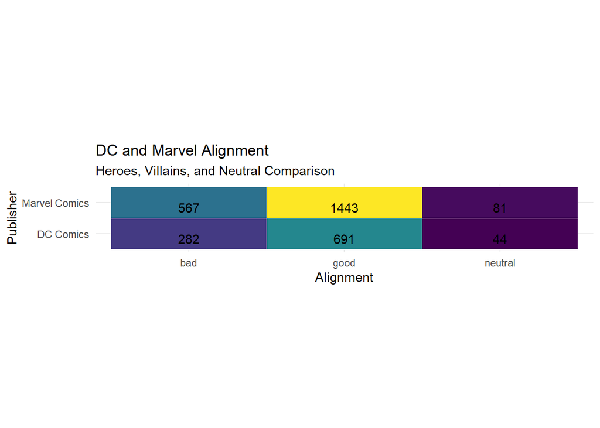

```r
library(viridis)
ggplot(marvelDcAlignment, aes(x = Alignment, y = Publisher, fill = Count)) +
  geom_tile(color = "white") +
  geom_text(aes(label = Count), vjust = 1) +
  labs(x = "Alignment", y = "Publisher", title = "DC and Marvel Alignment",
       subtitle = "Heroes, Villains, and Neutral Comparison") +
  guides(fill = FALSE) +
  theme_minimal() +
  scale_fill_viridis() +
  coord_fixed(ratio = 0.2)
```

# Box Plot Comparison Skills Marvel and DC

## - Intelligence

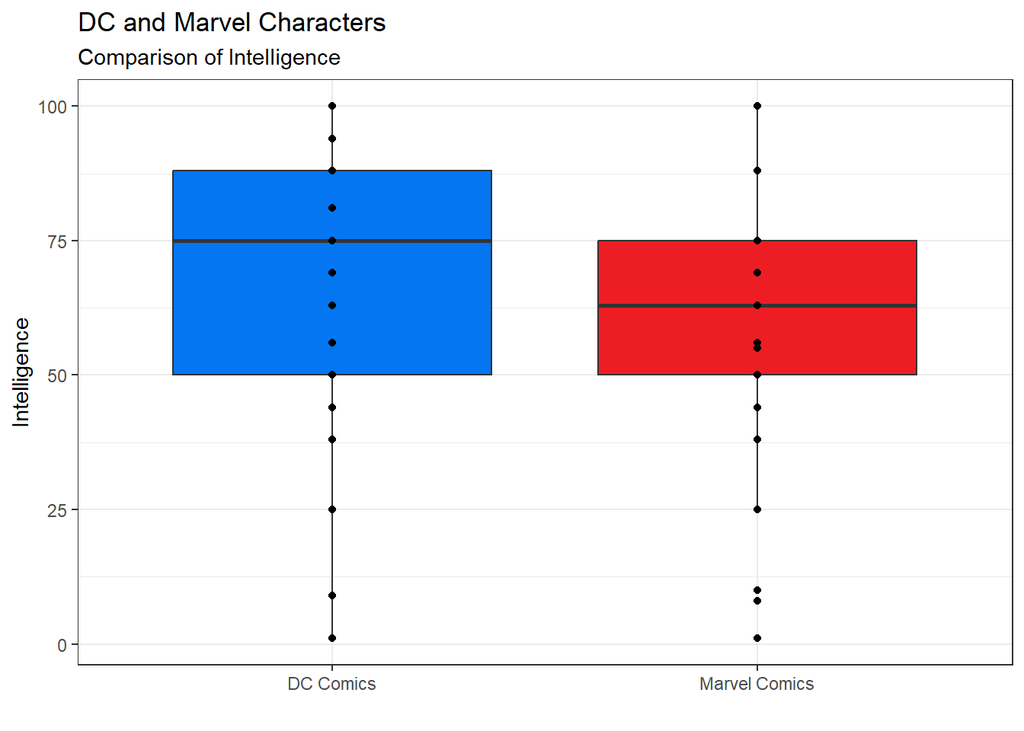

```r
### INTELLIGENCE
boxIntel <- ggplot(marvelDc, aes(x = Publisher, y = Intelligence, fill = Publisher)) +
  geom_boxplot() +
  geom_point()+
  labs(x = "", title = "DC and Marvel Characters", subtitle = "Comparison of Intelligence") +
  guides(fill = FALSE) +
  theme_bw() +
  scale_fill_manual(values=dcMarvelPalette)
boxIntel
```

# Alternate

**Shape of Violins:** The width and shape of the violins indicate the density of Intelligence scores. Wider areas suggest higher density.

**Boxplots:** The white-filled boxes inside the violins display the interquartile range (IQR) and median, providing a summary of the central tendency and spread of the data.

**Median Labels:** Text labels on top of the violins indicate the median Intelligence scores for DC and Marvel characters.

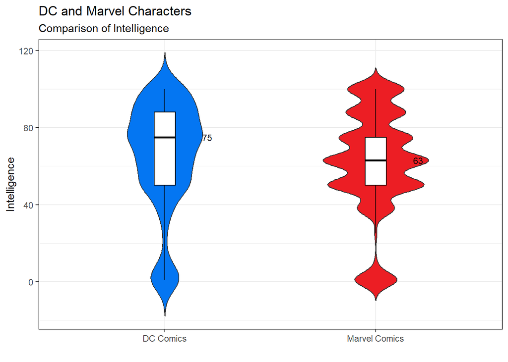

```r
ggplot(marvelDc, aes(x = Publisher, y = Intelligence, fill = Publisher)) +
  geom_violin(trim = FALSE, width = 0.5) +
  geom_boxplot(width = 0.1, outlier.shape = NA, fill = "white", color = "black") +
  labs(x = "", title = "DC and Marvel Characters", subtitle = "Comparison of Intelligence") +
  theme_bw() +
  scale_fill_manual(values = dcMarvelPalette) +
  theme(legend.position = "none") +
  stat_summary(geom = "text", fun = median, aes(label = round(..y.., 2)),
               position = position_nudge(x = 0.2), size = 3, color = "black")
```

## Strength

A brief box plot contrasts the abilities of DC and Marvel Characters.The x-axis remains discreet, y-axis define “strength”,and unique boxes represent each world.In this visual, the strength of heroes from DC and Marvel unfolds.

In terms of IQR DC superheroes have more variability then marvel characters.

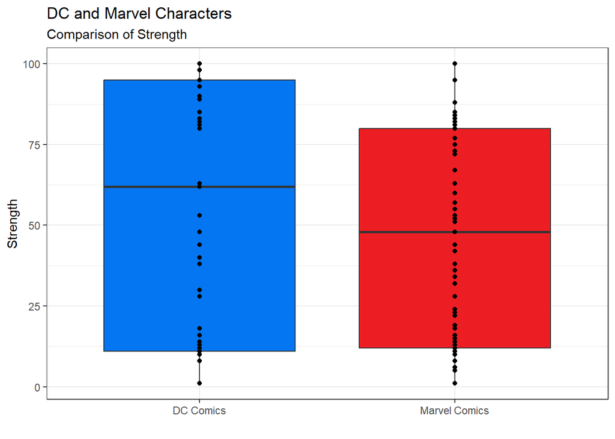

```r
### STRENGTH
boxStrength <- ggplot(marvelDc, aes(x = Publisher, y = Strength, fill = Publisher)) +
  geom_boxplot() +
  geom_point()+
  labs(x = "", title = "DC and Marvel Characters", subtitle = "Comparison of Strength") +
  guides(fill = FALSE) +
  theme_bw() +
  scale_fill_manual(values=dcMarvelPalette)
boxStrength
```

## Speed

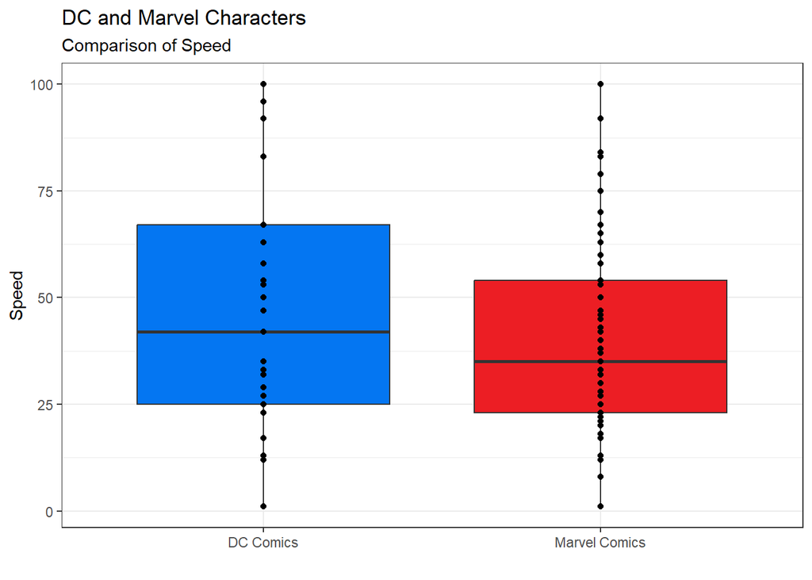

```r
### SPEED
boxSpeed <- ggplot(marvelDc, aes(x = Publisher, y = Speed, fill = Publisher)) +
  geom_boxplot() +
  geom_point()+
  labs(x = "", title = "DC and Marvel Characters", subtitle = "Comparison of Speed") +
  guides(fill = FALSE) +
  theme_bw() +
  scale_fill_manual(values=dcMarvelPalette)
boxSpeed
```

## Durability

Characters from DC and Marvel are compared in terms of durability. communicates variances in durability among these iconoic characters.

“Durability” represent characteristic or attribute of comic book characters, specifically their ability to endure or withstand physical damage or challenges.

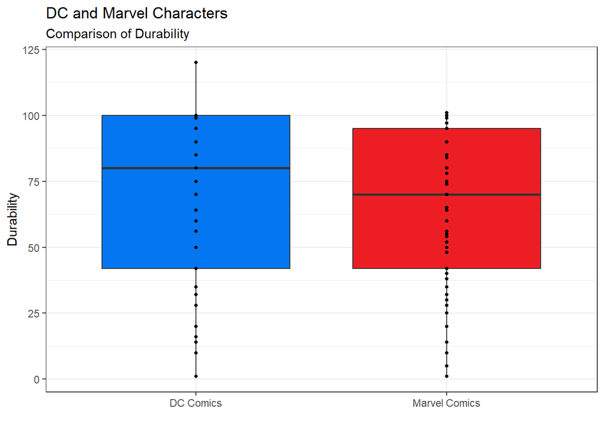

```r
### DURABILITY
boxDurability <- ggplot(marvelDc, aes(x = Publisher, y = Durability, fill = Publisher)) +
  geom_boxplot() +
  geom_point(size=1)+
  labs(x = "", title = "DC and Marvel Characters", subtitle = "Comparison of Durability") +
  guides(fill = FALSE) +
  theme_bw() +
  scale_fill_manual(values=dcMarvelPalette)
boxDurability
```

## Power

Characters from DC and Marvel are compared in terms of power.

Allowing for a swift comparison of power levels between the two universes.

marvel has lower median then DC, dc has more power and DC also beat marvel in terms of IQR too , more outliers near too wick belong too marvel exceptionally powerful heroes.

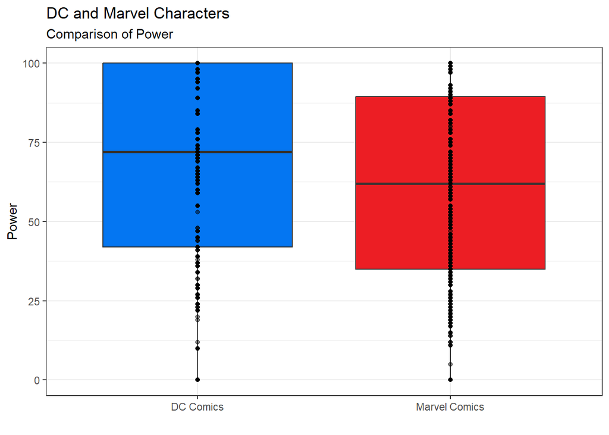

```r
### POWER
boxPower <- ggplot(marvelDc, aes(x = Publisher, y = Power, fill = Publisher)) +
  geom_boxplot() +
  geom_point(alpha = 0.5)+
  labs(x = "", title = "DC and Marvel Characters", subtitle = "Comparison of Power") +
  guides(fill = FALSE) +
  theme_bw() +
  scale_fill_manual(values=dcMarvelPalette)
boxPower
```

## Combat

here i create concise graph for attributes like intellect, strength, speed, Durability,power,and combat,comparing DC and Marvel Characters.

and showing every box plot here…

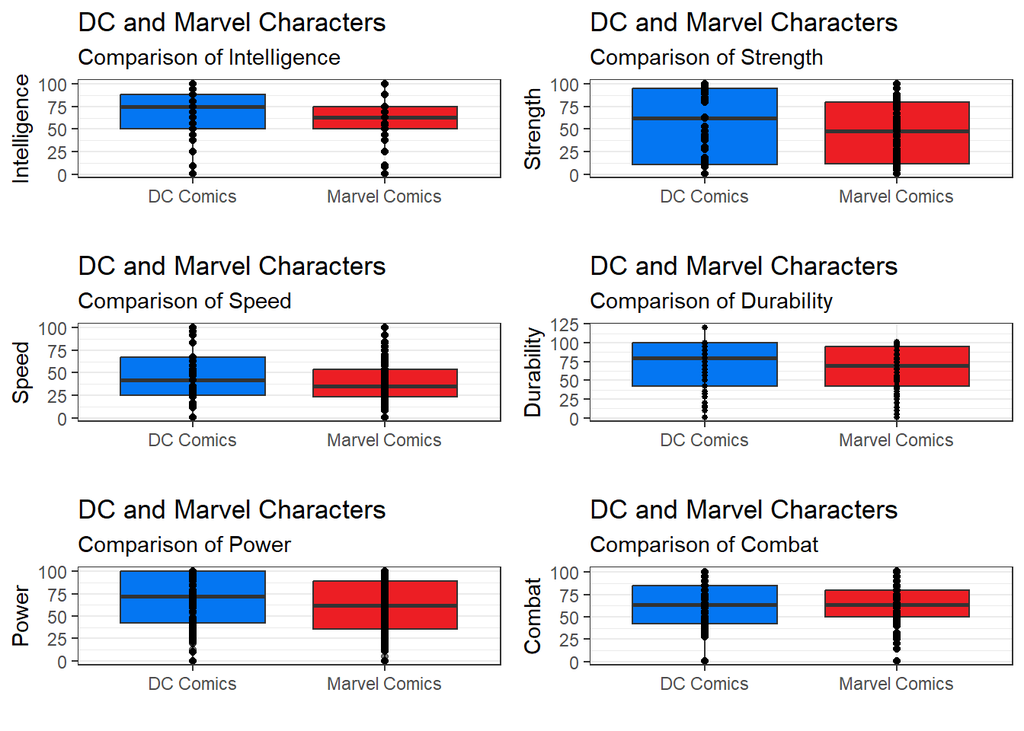

```r
### COMBAT
boxCombat <- ggplot(marvelDc, aes(x = Publisher, y = Combat, fill = Publisher)) +
  geom_boxplot() +
  geom_point()+
  labs(x = "", title = "DC and Marvel Characters", subtitle = "Comparison of Combat") +
  guides(fill = FALSE) +
  theme_bw() +
  scale_fill_manual(values=dcMarvelPalette)

grid.arrange(boxIntel, boxStrength, boxSpeed, boxDurability, boxPower, boxCombat,  ncol = 2)
```

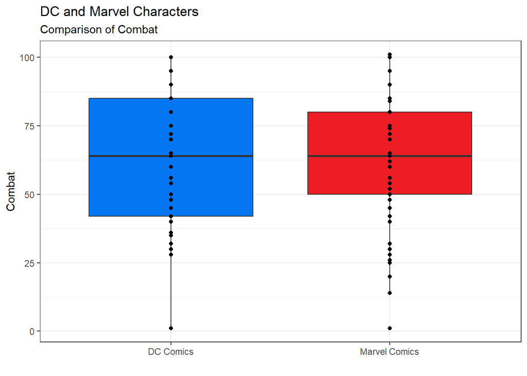

```r
boxCombat
```